# Term paper video game

Teo Ming Jun

4/12/2023

merging dataset to have user scores as well as sales

```
##                                      Name Platform  Rank Year        Genre
## 1            ¡Shin Chan Flipa en colores!       ds  9137 2007     Platform
## 2       .hack: Sekai no Mukou ni + Versus      ps3 14279 2012       Action
## 3              .hack//G.U. Vol.1//Rebirth      ps2  8359 2006 Role-Playing
## 4            .hack//G.U. Vol.2//Reminisce      ps2  7109 2006 Role-Playing
## 5 .hack//G.U. Vol.2//Reminisce (jp sales)      ps2  8604 2006 Role-Playing
## 6           .hack//G.U. Vol.3//Redemption      ps2  8306 2007 Role-Playing
##            Publisher NA_Sales EU_Sales JP_Sales Other_Sales Global_Sales
## 1          505 Games     0.00     0.00     0.14        0.00         0.14
## 2 Namco Bandai Games     0.00     0.00     0.03        0.00         0.03
## 3 Namco Bandai Games     0.00     0.00     0.17        0.00         0.17
## 4 Namco Bandai Games     0.11     0.09     0.00        0.03         0.23
## 5 Namco Bandai Games     0.00     0.00     0.16        0.00         0.16
## 6 Namco Bandai Games     0.00     0.00     0.17        0.00         0.17
##   metascore userscore date
## 1        NA      <NA> <NA>
## 2        NA      <NA> <NA>
## 3        NA      <NA> <NA>
## 4        NA      <NA> <NA>
## 5        NA      <NA> <NA>
## 6        NA      <NA> <NA>
```

```
##            Var1 Freq
## 1        Action 1280
## 2     Adventure  201
## 3      Fighting  297
## 4          Misc  318
## 5      Platform  341
## 6        Puzzle  123
## 7        Racing  423
## 8  Role-Playing  619
## 9       Shooter  677
## 10   Simulation  235
## 11       Sports  738
## 12     Strategy  262
```

[figure not shown]

```
##                                        Frequency   Percent
## Electronic Arts                              728 13.202757
## Activision                                   368  6.673921
## Ubisoft                                      364  6.601378
## Nintendo                                     303  5.495103
## Sony Computer Entertainment                  276  5.005441
## Sega                                         260  4.715270
## THQ                                          236  4.280015
## Take-Two Interactive                         220  3.989844
## Konami Digital Entertainment                 213  3.862894
## Namco Bandai Games                           206  3.735945
## Capcom                                       180  3.264418
## Atari                                        147  2.665941
## Square Enix                                  123  2.230686
## Tecmo Koei                                   118  2.140007
## Eidos Interactive                            104  1.886108
## Codemasters                                   99  1.795430
## Microsoft Game Studios                        90  1.632209
## Warner Bros. Interactive Entertainment        90  1.632209
## Vivendi Games                                 86  1.559666
## Midway Games                                  80  1.450852
```

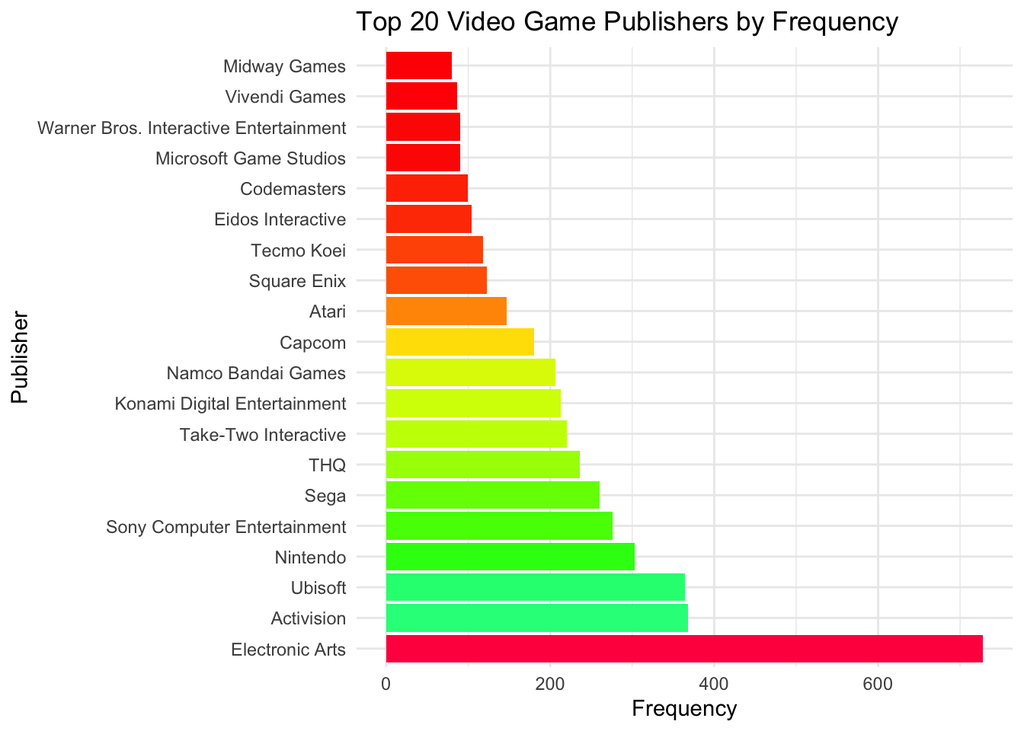

```
##                                           Name Platform Rank Year    Genre
## 1                                   Wii Sports      wii    1 2006   Sports
## 2                               Mario Kart Wii      wii    3 2008   Racing
## 3                            Wii Sports Resort      wii    4 2009   Sports
## 4                        New Super Mario Bros.       ds    7 2006 Platform
## 5                                     Wii Play      wii    8 2006     Misc
## 6                    New Super Mario Bros. Wii      wii    9 2009 Platform
## 7                                Mario Kart DS       ds   12 2005   Racing
## 8                                      Wii Fit      wii   14 2007   Sports
## 9                                 Wii Fit Plus      wii   15 2009   Sports
## 10                          Kinect Adventures!     x360   16 2010     Misc
## 11                          Grand Theft Auto V      ps3   17 2013   Action
## 12               Grand Theft Auto: San Andreas      ps2   18 2004   Action
## 13                          Grand Theft Auto V     x360   24 2013   Action
## 14                 Grand Theft Auto: Vice City      ps2   25 2002   Action
```

[output cut: 48 more lines]

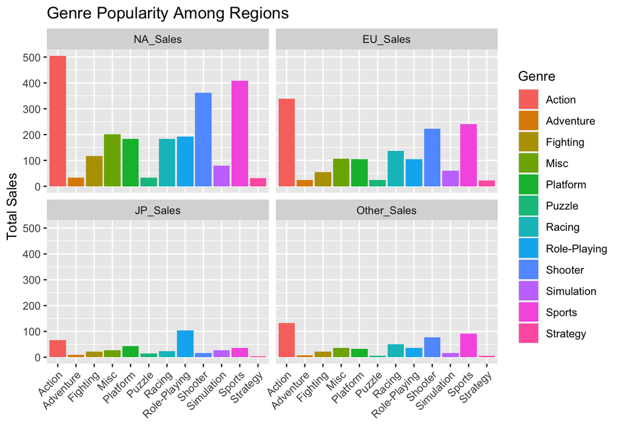

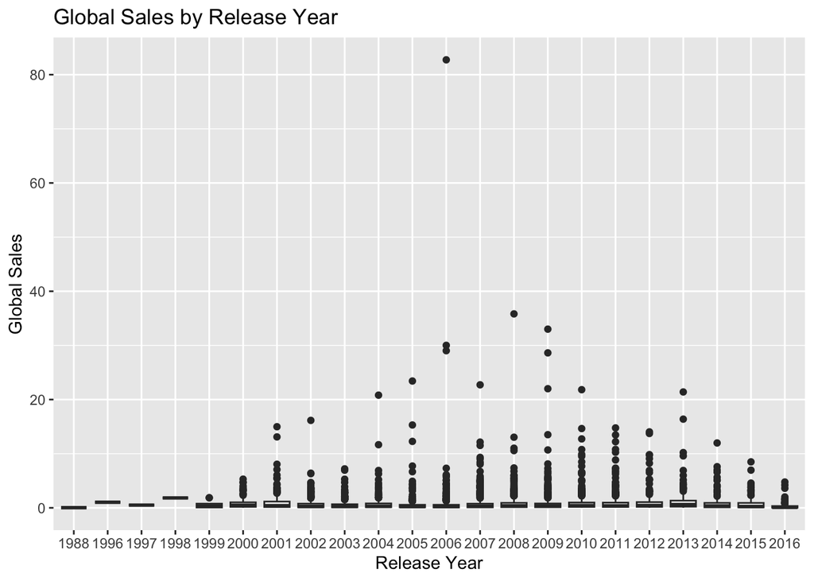

```
##                      Year    NA_Sales   EU_Sales    JP_Sales Other_Sales
## Year          1.000000000 0.001276971 0.05924118 -0.01834722  0.04335204
## NA_Sales      0.001276971 1.000000000 0.85145182  0.47378737  0.72996618
## EU_Sales      0.059241181 0.851451816 1.00000000  0.51076751  0.72088625
## JP_Sales     -0.018347217 0.473787366 0.51076751  1.00000000  0.39287189
## Other_Sales   0.043352038 0.729966176 0.72088625  0.39287189  1.00000000
## Global_Sales  0.024757788 0.959269070 0.94165725  0.60701108  0.80672455
## metascore     0.009696543 0.233193675 0.21724439  0.14544405  0.20518465
## userscore    -0.241737722 0.090457547 0.06094481  0.13805123  0.07189396
##              Global_Sales   metascore   userscore
## Year           0.02475779 0.009696543 -0.24173772
## NA_Sales       0.95926907 0.233193675  0.09045755
## EU_Sales       0.94165725 0.217244389  0.06094481
## JP_Sales       0.60701108 0.145444052  0.13805123
## Other_Sales    0.80672455 0.205184650  0.07189396
## Global_Sales   1.00000000 0.239969732  0.09528453
## metascore      0.23996973 1.000000000  0.57065558
## userscore      0.09528453 0.570655583  1.00000000
```

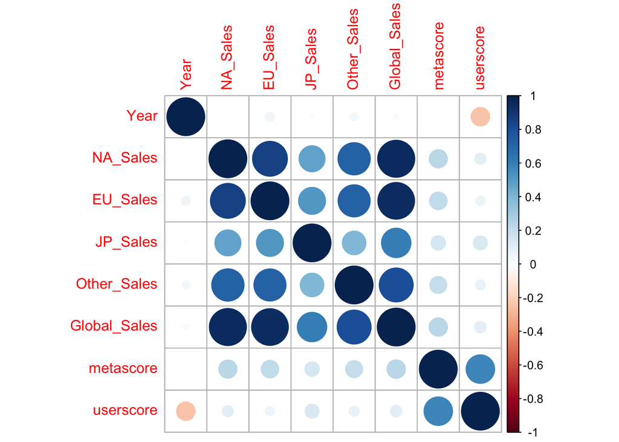

Global Sales are correlated with NA_SALES, EU_SALES, JP_sales, and other sales, makes sense as they are dependatn on each other. Will train the model with each as response.

```
## Test RMSE: 0.567
```

```
##                                             Feature         Gain        Cover
##  1:                                        NA_Sales 5.419694e-01 3.464663e-01
##  2:                                     Other_Sales 3.111877e-01 2.323242e-01
##  3:                                        EU_Sales 8.153818e-02 2.054907e-01
##  4:                                        JP_Sales 4.065944e-02 1.331012e-01
##  5:                                     GenreSports 3.432994e-03 1.752655e-04
##  6:                        PublisherElectronic Arts 3.074217e-03 1.714789e-04
##  7:                                       userscore 2.930711e-03 3.926163e-03
##  8:                                     Platformps3 2.077189e-03 5.849215e-03
##  9:                                     Platformps2 1.915971e-03 4.057072e-03
## 10:                               PublisherNintendo 1.596038e-03 4.926367e-03
## 11:                                     Platformpsp 1.569425e-03 9.506530e-03
## 12:                                       metascore 1.410848e-03 1.703700e-02
## 13:                                    Platformx360 1.237596e-03 3.572928e-03
## 14:                                            Year 1.086551e-03 7.495305e-03
```

[output cut: 97 more lines]

Different publishers would be more sellable in different regions, Japanese games will do better in JP, for eg.

```
## Test RMSE: 1.122
```

```
##                                             Feature         Gain        Cover
##  1:                                       metascore 3.045773e-01 2.062204e-01
##  2:                                       userscore 1.471790e-01 8.178334e-02
##  3:                                            Year 1.050694e-01 6.960475e-02
##  4:                               PublisherNintendo 6.650576e-02 5.247263e-02
##  5:                                     Platformwii 5.486458e-02 2.612409e-02
##  6:                                    GenreShooter 3.645464e-02 1.262153e-02
##  7:                                     GenreRacing 3.214283e-02 9.808635e-03
##  8:                   PublisherTake-Two Interactive 2.332301e-02 7.698286e-03
##  9:                                       GenreMisc 2.302151e-02 2.241773e-02
## 10:                                     GenreSports 2.159448e-02 1.242413e-02
## 11:                                      Platformpc 1.937814e-02 2.899378e-02
## 12:                 PublisherMicrosoft Game Studios 1.556506e-02 3.697168e-02
## 13:                                    Platformx360 1.423139e-02 6.882703e-03
## 14:                             PublisherActivision 1.330121e-02 2.491207e-02
```

[output cut: 155 more lines]

take two games sold vs nintendo

```
## Test RMSE: 1.076
```

```
##                                             Feature         Gain        Cover
##  1:                                       metascore 3.149868e-01 1.868087e-01
##  2:                                            Year 1.323210e-01 5.333904e-02
##  3:                                       userscore 1.101891e-01 8.288557e-02
##  4:                                     Platformwii 4.586960e-02 2.690346e-02
##  5:                               PublisherNintendo 4.300633e-02 6.213973e-02
##  6:                                    GenreShooter 3.645581e-02 8.113991e-03
##  7:                                    Platformx360 3.499650e-02 1.523764e-02
##  8:                                      Platformpc 3.403847e-02 2.187179e-02
##  9:                                     GenreSports 3.050614e-02 7.420266e-03
## 10:                                     GenreRacing 2.678426e-02 9.735925e-03
## 11:                 PublisherMicrosoft Game Studios 2.338172e-02 4.744940e-02
## 12:                                       GenreMisc 2.218334e-02 2.171565e-02
## 13:                             PublisherActivision 1.689602e-02 3.351654e-02
## 14:                   PublisherTake-Two Interactive 1.586845e-02 1.540783e-02
```

[output cut: 147 more lines]

```
## Test RMSE: 1.143
```

```
##                                             Feature         Gain        Cover
##  1:                                       metascore 3.027161e-01 2.015773e-01
##  2:                                       userscore 1.384360e-01 6.297701e-02
##  3:                                            Year 1.150658e-01 6.630787e-02
##  4:                                     Platformwii 5.425762e-02 3.046620e-02
##  5:                                     GenreRacing 4.770914e-02 1.205234e-02
##  6:                               PublisherNintendo 4.456970e-02 5.531786e-02
##  7:                                     GenreSports 3.354646e-02 1.833922e-02
##  8:                                    GenreShooter 2.855872e-02 6.360986e-03
##  9:                                     Platformps3 2.280482e-02 1.874922e-02
## 10:                   PublisherTake-Two Interactive 1.788887e-02 8.123239e-03
## 11:                                       GenreMisc 1.566347e-02 1.722172e-02
## 12:                                 GenreSimulation 1.536633e-02 1.316281e-02
## 13:                             PublisherActivision 1.465072e-02 2.637808e-02
## 14:                                      Platformpc 1.404855e-02 2.188212e-02
```

[output cut: 153 more lines]

```
## Test RMSE: 1.196
```

```
##                                         Feature         Gain        Cover
##  1:                                   metascore 1.759844e-01 1.012655e-01
##  2:                                        Year 1.646714e-01 5.728955e-02
##  3:                           PublisherNintendo 1.475139e-01 9.475315e-02
##  4:                                   userscore 1.009061e-01 1.103756e-01
##  5:                                 Platformpsp 5.379023e-02 1.362554e-02
##  6:                           GenreRole-Playing 3.493787e-02 2.907059e-02
##  7:                        PublisherSquare Enix 3.085123e-02 4.201807e-02
##  8:                                 Platformwii 2.902438e-02 5.166014e-03
##  9:                             PublisherCapcom 2.452381e-02 4.784375e-02
## 10:                                 Platformps2 2.449709e-02 1.368231e-02
## 11:                                 GenreSports 2.329105e-02 4.838339e-03
## 12:                                 GenreRacing 2.054416e-02 6.077123e-03
## 13:                                 Platform3ds 1.897866e-02 1.799778e-02
## 14:                               GenreFighting 1.687190e-02 3.896409e-03
```

[output cut: 127 more lines]

```
## Test RMSE: 1.056
```

```
##                                             Feature         Gain        Cover
##  1:                                       metascore 2.504873e-01 2.306061e-01
##  2:                                            Year 1.881146e-01 5.716962e-02
##  3:                   PublisherTake-Two Interactive 1.214209e-01 1.042549e-02
##  4:                                     Platformps2 1.158485e-01 3.567754e-02
##  5:                                       userscore 9.097446e-02 8.653307e-02
##  6:                                     Platformps3 2.318058e-02 2.516325e-02
##  7:                                     GenreRacing 2.139732e-02 1.121170e-02
##  8:                                     Platformwii 1.832400e-02 2.215755e-02
##  9:                               PublisherNintendo 1.572550e-02 3.988098e-02
## 10:                             PublisherActivision 1.505223e-02 1.973609e-02
## 11:                                    GenreShooter 1.496808e-02 9.410229e-03
## 12:                                     GenreSports 1.421140e-02 9.307891e-03
## 13:                                      Platformpc 1.364948e-02 1.630966e-02
## 14:                                       GenreMisc 9.283915e-03 2.253712e-02
```

[output cut: 141 more lines]

I will slightly favour the user scores as user scores may be more important in industries such as gaming, where the target audience is the general public.

```
##
## Call:
## lm(formula = Global_Sales ~ total_score, data = global_train)
##
## Residuals:
##     Min      1Q  Median      3Q     Max
## -0.6513 -0.3306 -0.1707  0.0424 16.3383
##
## Coefficients:
##             Estimate Std. Error t value Pr(>|t|)
## (Intercept) -0.97315    0.07956  -12.23   <2e-16 ***
## total_score  0.13484    0.01099   12.27   <2e-16 ***
## ---
## Signif. codes:  0 '***' 0.001 '**' 0.01 '*' 0.05 '.' 0.1 ' ' 1
##
## Residual standard error: 0.8199 on 3857 degrees of freedom
## Multiple R-squared:  0.03757,    Adjusted R-squared:  0.03732
## F-statistic: 150.6 on 1 and 3857 DF,  p-value: < 2.2e-16
```

```
## [1] 1.291323
```

```
##              Overall
## total_score 12.26998
```

```
##
## Call:
## lm(formula = total_score ~ Global_Sales, data = global_train)
##
## Residuals:
##     Min      1Q  Median      3Q     Max
## -5.5576 -0.6324  0.2314  0.8623  2.1922
##
## Coefficients:
##              Estimate Std. Error t value Pr(>|t|)
## (Intercept)   7.14234    0.01897  376.43   <2e-16 ***
## Global_Sales  0.27861    0.02271   12.27   <2e-16 ***
## ---
## Signif. codes:  0 '***' 0.001 '**' 0.01 '*' 0.05 '.' 0.1 ' ' 1
##
## Residual standard error: 1.179 on 3857 degrees of freedom
## Multiple R-squared:  0.03757,    Adjusted R-squared:  0.03732
## F-statistic: 150.6 on 1 and 3857 DF,  p-value: < 2.2e-16
```

```
## [1] 1.209159
```

```
##               Overall
## Global_Sales 12.26998
```

To incorporate causal inference methods, you may want to use techniques such as propensity score matching, instrumental variable regression, or difference-in-differences analysis. These methods typically require additional data and assumptions, and may be beyond the scope of what can be implemented within the context of this code snippet. It is recommended that you consult with a statistician or data scientist with expertise in causal inference methods if you are interested in pursuing this type of analysis.

Causal inference is a broad topic that encompasses several different techniques, including regression adjustment, propensity score matching, and instrumental variable analysis. Each method has its own strengths and limitations, and the choice of method will depend on the specific research question and data available.

One possible way to extend the code would be to use propensity score matching to estimate the causal effect of ratings on sales. Propensity score matching involves creating a pseudo-population in which the distribution of confounding variables is balanced between the treatment and control groups. In this case, the treatment group would be games with high ratings, and the control group would be games with low ratings. After balancing the distribution of confounding variables, you can estimate the causal effect of ratings on sales using a regression model.

SUBSET GLOBAL DATA INSTEAD OF GLOBAL TRAIN

```
##
## Call:
## lm(formula = Global_Sales ~ high_rating + Publisher + Year, data = matched_data)
##
## Residuals:
##    Min     1Q Median     3Q    Max
## -2.621 -0.608 -0.211  0.138 33.424
##
## Coefficients:
##                                                   Estimate Std. Error t value
## (Intercept)                                     -6.767e+01  1.665e+01  -4.065
## high_rating                                      5.116e-01  5.912e-02   8.653
## Publisher3DO                                     7.147e-01  1.133e+00   0.631
## Publisher505 Games                               6.863e-01  1.052e+00   0.652
## PublisherAcclaim Entertainment                   7.352e-01  1.067e+00   0.689
## PublisherAcquire                                 4.104e-01  1.622e+00   0.253
## PublisherActivision                              1.499e+00  1.032e+00   1.453
## PublisherAksys Games                             2.131e-01  1.622e+00   0.131
## PublisherAQ Interactive                          9.433e-02  2.051e+00   0.046
## PublisherAscaron Entertainment GmbH              4.459e-01  2.052e+00   0.217
## PublisherAspyr                                   1.801e-01  1.622e+00   0.111
## PublisherAstragon                                1.378e-01  2.052e+00   0.067
## PublisherAtari                                   7.417e-01  1.039e+00   0.713
## PublisherAtlus                                   2.942e-01  1.138e+00   0.258
## PublisherAvalon Interactive                      3.577e-01  1.623e+00   0.220
## PublisherAvanquest                               1.378e-01  2.052e+00   0.067
## PublisherBAM! Entertainment                      6.605e-01  1.228e+00   0.538
## PublisherBanpresto                               3.334e-01  1.622e+00   0.206
## PublisherBethesda Softworks                      1.451e+00  1.074e+00   1.351
## PublisherBlack Bean Games                        5.142e-01  1.622e+00   0.317
## PublisherBlack Label Games                       1.787e+00  2.053e+00   0.870
## PublisherBrash Entertainment                     4.959e-01  2.052e+00   0.242
## PublisherCapcom                                  6.681e-01  1.037e+00   0.644
## PublisherCity Interactive                        6.849e-01  1.203e+00   0.569
## PublisherCodemasters                             4.337e-01  1.042e+00   0.416
## PublisherCompile Heart                           3.084e-01  1.622e+00   0.190
## PublisherConspiracy Entertainment                3.689e-01  2.052e+00   0.180
## PublisherCrave Entertainment                     4.029e-01  1.227e+00   0.328
## PublisherD3Publisher                             3.645e-01  1.091e+00   0.334
## PublisherDaedalic                               -4.918e-02  2.051e+00  -0.024
```

[output cut: 300 more lines]

```
## PublisherVivendi Games                            0.5620
## PublisherWanadoo                                  0.8000
## PublisherWargaming.net                            0.7791
## PublisherWarner Bros. Interactive Entertainment   0.3660
## PublisherXplosiv                                  0.7380
## PublisherZoo Digital Publishing                   0.6879
## PublisherZoo Games                                0.9320
## PublisherZushi Games                              0.8015
## Year                                            5.08e-05 ***
## ---
## Signif. codes:  0 '***' 0.001 '**' 0.01 '*' 0.05 '.' 0.1 ' ' 1
##
## Residual standard error: 1.776 on 3945 degrees of freedom
## Multiple R-squared:  0.1134, Adjusted R-squared:  0.07567
## F-statistic: 3.004 on 168 and 3945 DF,  p-value: < 2.2e-16
```

```
## high_rating
##   0.5115849
```

```
## high_rating
##    42.33342
```

6.6 million

hits are more than 1 million sales how to unnormalize

```
##  65%
## 0.56
```

```
##
## Call:
## lm(formula = total_score ~ high_sales + Publisher + Year, data = matched_data)
##
## Residuals:
##     Min      1Q  Median      3Q     Max
## -4.6645 -0.4393  0.1100  0.6069  2.3339
##
## Coefficients:
##                                                   Estimate Std. Error t value
## (Intercept)                                     135.976041  12.473432  10.901
## high_sales                                        0.656814   0.048562  13.525
## Publisher2D Boy                                   0.568996   1.419756   0.401
## Publisher3DO                                     -2.878512   1.124196  -2.561
## Publisher505 Games                               -1.886461   1.026570  -1.838
## Publisher5pb                                     -0.340000   1.419635  -0.239
## PublisherAcclaim Entertainment                   -1.210228   1.038411  -1.165
## PublisherAckkstudios                             -0.563668   1.419649  -0.397
## PublisherAcquire                                 -1.431004   1.419756  -1.008
## PublisherActivision                              -1.380800   1.007177  -1.371
## PublisherActivision Blizzard                     -0.728996   1.419756  -0.513
## PublisherAgatsuma Entertainment                  -0.494498   1.229475  -0.402
## PublisherAgetec                                  -0.893011   1.420725  -0.629
## PublisherAksys Games                             -0.405329   1.229689  -0.330
## PublisherAQ Interactive                           0.068996   1.419756   0.049
## PublisherArc System Works                         0.487336   1.419689   0.343
## PublisherAscaron Entertainment GmbH              -1.211004   1.419756  -0.853
## PublisherASCII Entertainment                     -1.151350   1.422271  -0.810
## PublisherAspyr                                   -1.407336   1.419689  -0.991
## PublisherAstragon                                -2.181661   1.419972  -1.536
## PublisherAtari                                   -1.261989   1.015216  -1.243
## PublisherAtlus                                    0.404221   1.159135   0.349
## PublisherAvalon Interactive                      -3.365675   1.420295  -2.370
## PublisherAvanquest                               -3.561661   1.419972  -2.508
## PublisherBAM! Entertainment                      -3.051177   1.123550  -2.716
## PublisherBanpresto                               -0.821090   1.122883  -0.731
## PublisherBethesda Softworks                      -0.581486   1.022100  -0.569
## PublisherbitComposer Games                       -0.587336   1.419689  -0.414
## PublisherBlack Bean Games                        -2.149170   1.229537  -1.748
## PublisherBlack Label Games                       -4.169824   1.421600  -2.933
```

[output cut: 430 more lines]

```
## PublisherWarner Bros. Interactive Entertainment 0.338294
## PublisherWhite Park Bay Software                0.727578
## PublisherXplosiv                                0.000415 ***
## PublisherXseed Games                            0.941794
## PublisherYacht Club Games                       0.528688
## PublisherZoo Digital Publishing                 0.007901 **
## PublisherZoo Games                              0.417628
## PublisherZushi Games                            0.293756
## Year                                             < 2e-16 ***
## ---
## Signif. codes:  0 '***' 0.001 '**' 0.01 '*' 0.05 '.' 0.1 ' ' 1
##
## Residual standard error: 1.004 on 2076 degrees of freedom
## Multiple R-squared:  0.3319, Adjusted R-squared:  0.257
## F-statistic: 4.427 on 233 and 2076 DF,  p-value: < 2.2e-16
```

```
## high_sales
##  0.6568138
```

K means clustering for the impact of publishers on sales.

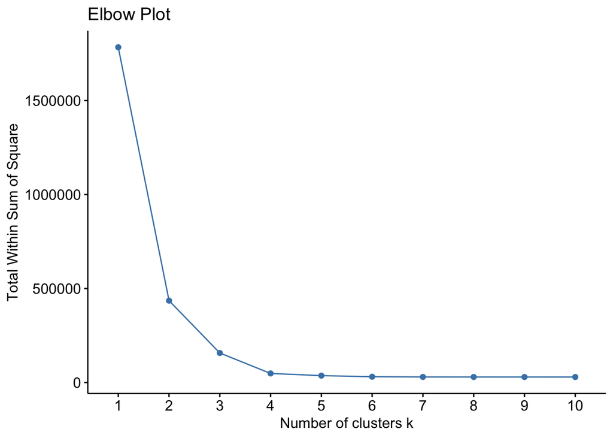

```
## # A tibble: 232 × 3
##    Publisher             total_sales cluster
##    <fct>                       <dbl> <fct>
##  1 1C Company                   0.1  2
##  2 2D Boy                       0.04 2
##  3 3DO                          2.82 2
##  4 505 Games                   29.3  1
##  5 5pb                          0.04 2
##  6 Acclaim Entertainment       18.0  2
##  7 Ackkstudios                  0.11 2
##  8 Acquire                      0.25 2
##  9 Activision                 447.   4
## 10 Activision Blizzard          0.48 2
## # ℹ 222 more rows
```

[figure not shown]

```
## # A tibble: 34 × 3
## # Groups:   cluster [5]
##    Publisher                  total_sales cluster
##    <fct>                            <dbl> <fct>
##  1 Atari                             74.5 1
##  2 Bethesda Softworks                69.6 1
##  3 LucasArts                         67.6 1
##  4 Midway Games                      40.0 1
##  5 Eidos Interactive                 39.0 1
##  6 Vivendi Games                     37.0 1
##  7 Codemasters                       34.0 1
##  8 Tecmo Koei                        30.8 1
##  9 505 Games                         29.3 1
## 10 Disney Interactive Studios        28.7 1
## # ℹ 24 more rows
```